```r
3+2
```

```
[1] 5
```

#### Drill One

This plot, based on the NHANES data table, shows the distribution of heights among males and females.

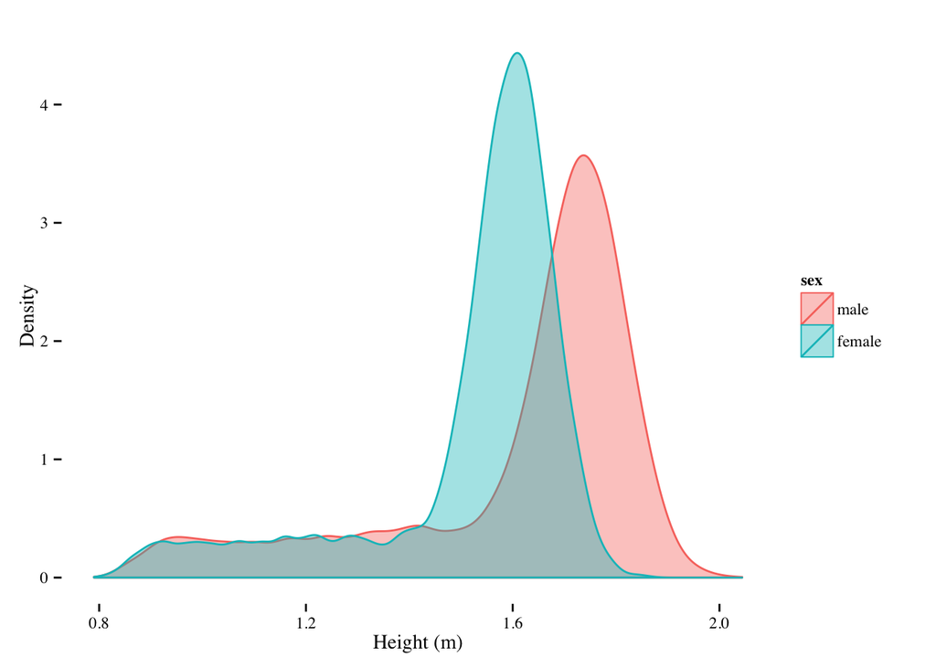

Explain briefly what the plot shows about height and sex.

### Drill Two

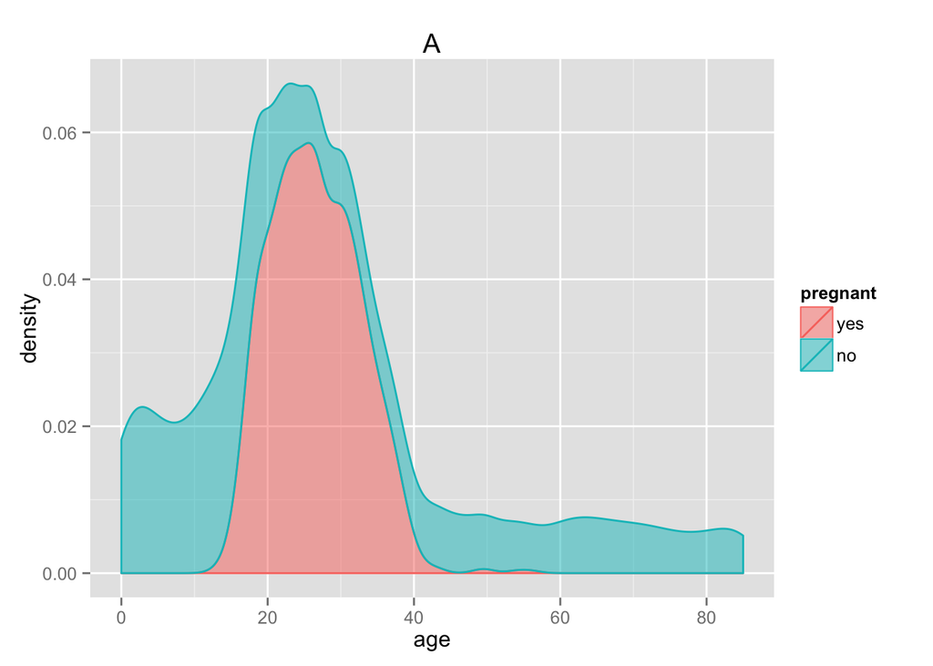

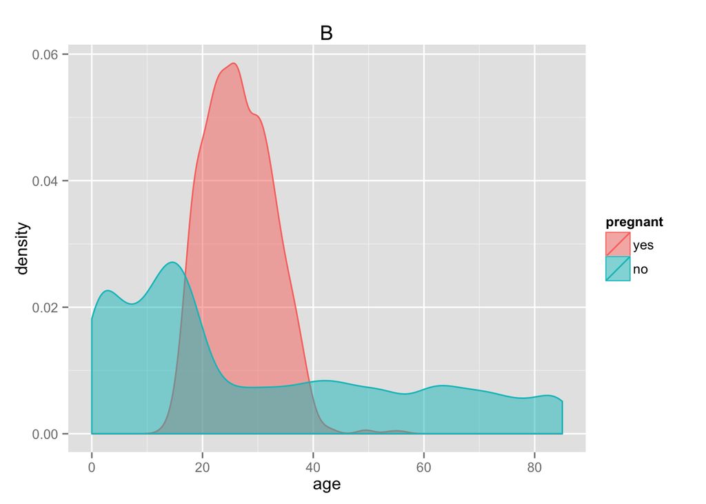

Explain briefly what’s different in the graphical setup between graph A and graph B and which one you think would be more useful in demonstrating the relationship between pregnancy and age.

MULTIPLE CHOICE

### Drill Three

There is often a choice between using color and using location to display a variable. The following two plots are based on the variables in the same data (NHANES). Explain how the different variables are represented.

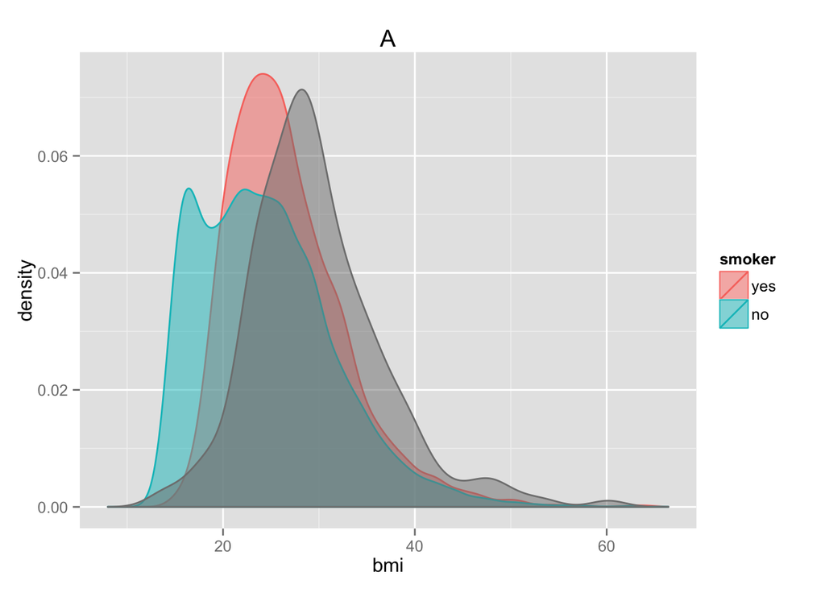

```r
ggplot(data=NHANES, aes(x=bmi,color=smoker,fill=smoker)) + geom_density(alpha=.5)  +
   labs(title="A")
```

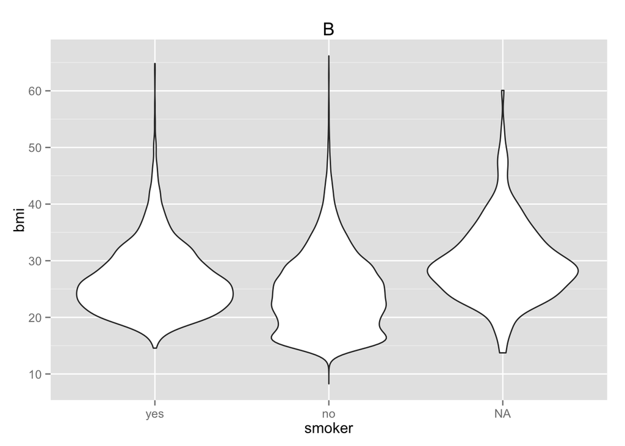

```r
ggplot(data=NHANES, aes(x=smoker, y=bmi)) + geom_violin()  +
  theme(legend.position="none") + labs(title="B")
```

### Exercise:

Make a graph from the NHANES data to indicate whether smokers are systematically lower in weight than non-smokers.

### FOR GRAPHICAL DECISIONS

Redo the NHANES mortality as a logistic regression.

Show fraction alive as a function of sex and smoking status.

Show proportion in each age of the height ntiles. Stack them.

### EXERCISE

FOR GRAMMAR SECTION: Density plots draw on cases collectively.

#### For design choices

Why not a histogram: Displaying two variables.

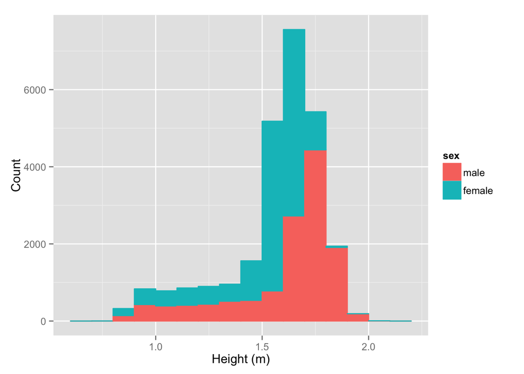

```r
ggplot(NHANES, aes(x=height)) +
    geom_histogram(aes(y = ..count..,color=sex,fill=sex),
                   binwidth=0.1) +
    xlab("Height (m)") + ylab("Count")
```

In talking about position/dodging, use this example of a misleading plot.

```
ymax not defined: adjusting position using y instead
```

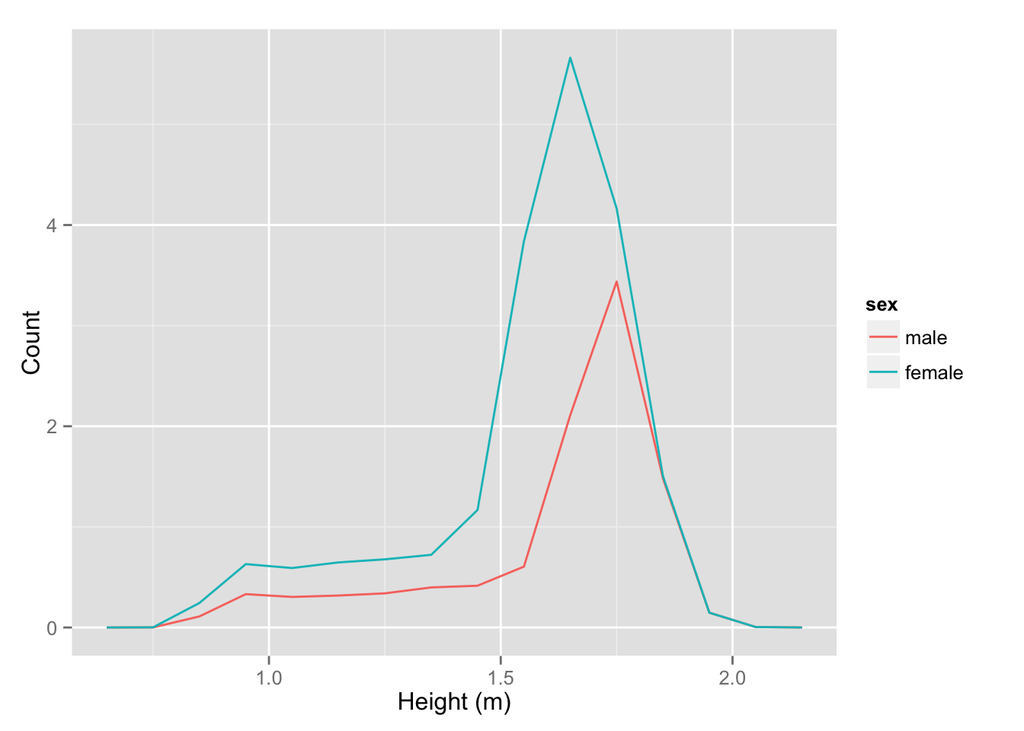

```r
ggplot(NHANES, aes(x=height)) +
    geom_freqpoly(aes(y = ..density.., color=sex),
                   binwidth=0.1, fill=NA, position="stack") +
    xlab("Height (m)") + ylab("Count")
```

Stacking bars or polygons or densities: make sure to fill them in so that the reader can figure out which group is which. If you want them to overlap, fill them with transluscent color.

##### Density Plots

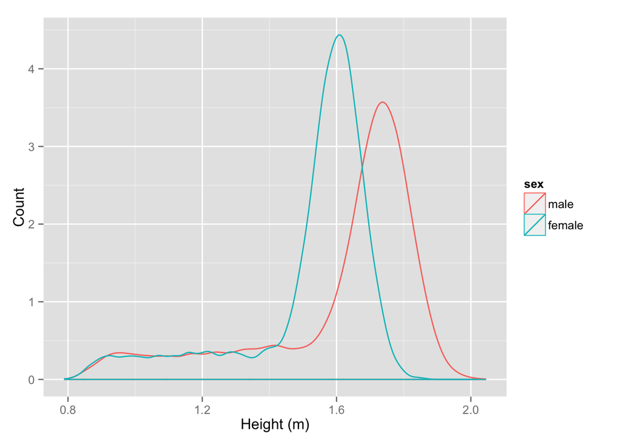

```r
ggplot(NHANES, aes(x=height)) +
    geom_density(aes(y = ..density.., color=sex),
                   binwidth=0.1, fill=NA) +
    xlab("Height (m)") + ylab("Count")
```

#### Design Decisions

Dealing with very large datasets:

- Transparency in scatter plots.
- Use densities rather than cases.

#### MOVE TO “Design Decisions”

In principle, the variables could be assigned to the other axes, but typically there is some purpose behind the use of a scatter plot, for instance to show how height varies with age. It’s conventional to put the *response variable* on the y-axis and the *explanatory variable* on the x-axis. Other terms for “explanatory variable” include “independent variable” or “causal variable.” The “response variable” is also known as the “dependent variable”, “result,” or “effect.”

Often, the size, shape, or color of the “dots” is used to show the value of another variable. For instance:

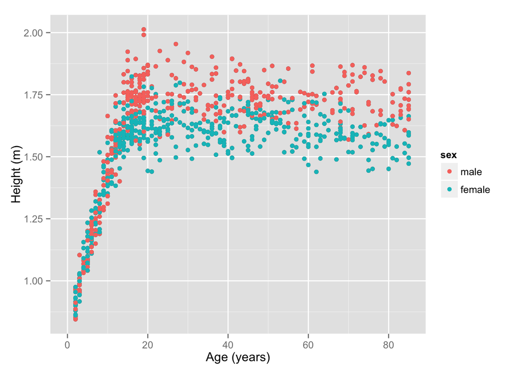